# Seaborn plots

```python
# Hide all warnings
import warnings
warnings.simplefilter('ignore')

# Data
import pandas as pd
import numpy as np

# Graphics
import matplotlib.pyplot as plt
import seaborn as sns

sns.set(font_scale=2, rc={'figure.figsize':(16,9)})

# Show plots directly within Jupyter Out
%matplotlib inline
```

```python
# https://www.kaggle.com/c/titanic/download/train.csv
df = pd.read_csv('train.csv')
df.head()
```

|  | PassengerId | Survived | Pclass | Name | Sex | Age | SibSp | Parch | Ticket | Fare | Cabin | Embarked |
| --- | --- | --- | --- | --- | --- | --- | --- | --- | --- | --- | --- | --- |
| 0 | 1 | 0 | 3 | Braund, Mr. Owen Harris | male | 22.0 | 1 | 0 | A/5 21171 | 7.2500 | NaN | S |
| 1 | 2 | 1 | 1 | Cumings, Mrs. John Bradley (Florence Briggs Th... | female | 38.0 | 1 | 0 | PC 17599 | 71.2833 | C85 | C |
| 2 | 3 | 1 | 3 | Heikkinen, Miss. Laina | female | 26.0 | 0 | 0 | STON/O2. 3101282 | 7.9250 | NaN | S |
| 3 | 4 | 1 | 1 | Futrelle, Mrs. Jacques Heath (Lily May Peel) | female | 35.0 | 1 | 0 | 113803 | 53.1000 | C123 | S |
| 4 | 5 | 0 | 3 | Allen, Mr. William Henry | male | 35.0 | 0 | 0 | 373450 | 8.0500 | NaN | S |

```python
df.shape
```

```
(891, 12)
```

```python
df.info()
```

```
<class 'pandas.core.frame.DataFrame'>
RangeIndex: 891 entries, 0 to 890
Data columns (total 12 columns):
PassengerId    891 non-null int64
Survived       891 non-null int64
Pclass         891 non-null int64
Name           891 non-null object
Sex            891 non-null object
Age            714 non-null float64
SibSp          891 non-null int64
Parch          891 non-null int64
Ticket         891 non-null object
Fare           891 non-null float64
Cabin          204 non-null object
Embarked       889 non-null object
dtypes: float64(2), int64(5), object(5)
memory usage: 83.6+ KB
```

# Heatmap

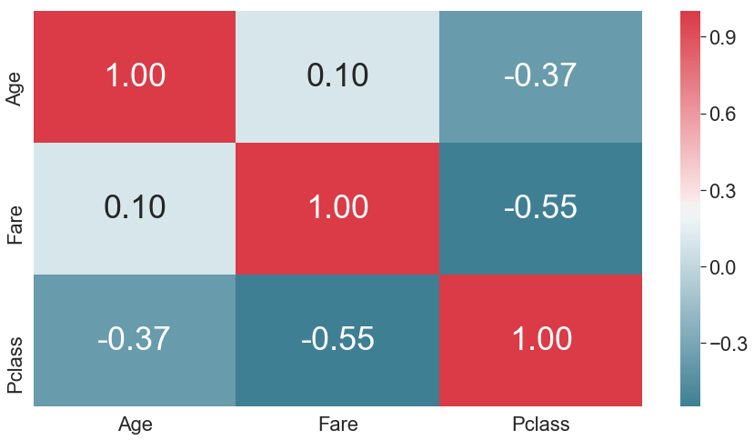

```python
f, ax = plt.subplots(figsize=(15, 8))
cmap = sns.diverging_palette(220, 10, as_cmap=True)

corr = df[['Age', 'Fare', 'Pclass']].corr()

sns.heatmap(corr, cmap=cmap, annot=True, fmt='.2f', annot_kws={"size": 36});
```

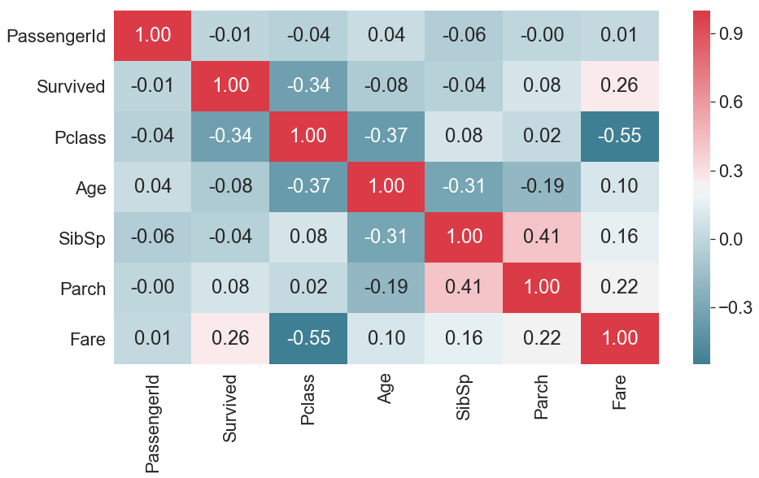

```python
# TODO: plot correlations between all variables
plt.figure(figsize=(15,8))
sns.heatmap(df.corr(),cmap=cmap,annot=True,fmt='.2f',annot_kws={"size": 24});
```

Heatmap ignores non-numerical data, so you don't see *Sex* variable here.

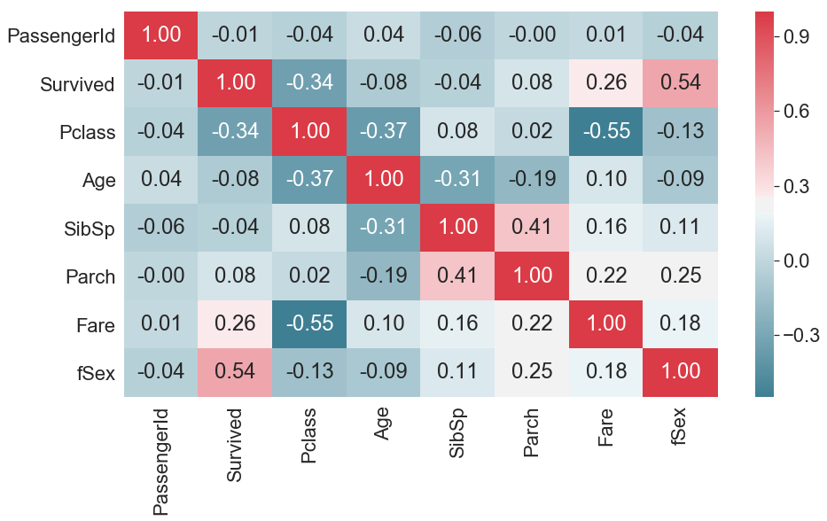

```python
# TODO: add new numerical variable fSex encoded variable Sex and replot heatmap
# use e.g. df['Sex'].factorize()

df['fSex'] = df['Sex'].factorize()[0]
plt.figure(figsize=(15,8))
sns.heatmap(df.corr(),cmap=cmap,annot=True,fmt='.2f',annot_kws={"size": 24});
```

Variable *Survived* is correlated to *fSex*, *Fare* and is anticorrelated to *Pclass*, but *Pclass* depends on *Fare* obviously.

## How much missing data we have

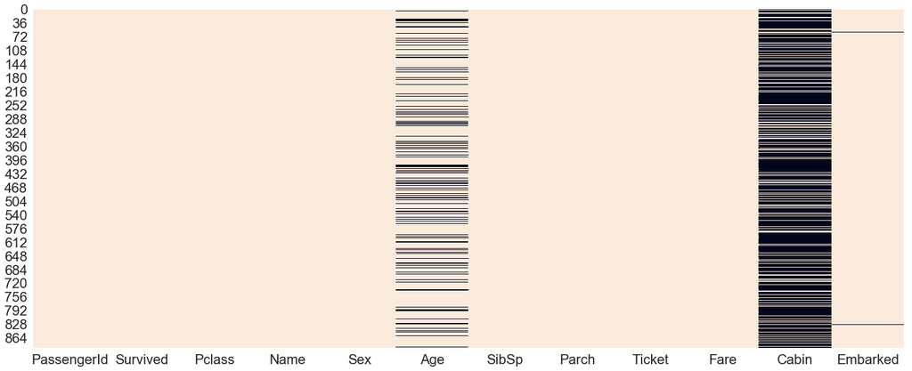

```python
fig, ax = plt.subplots(figsize=(25,10))
sns.heatmap(df.notnull(), cbar=False);  # cbar - color bar matching shades of colors with numbers
                                        # use semicolon not to print info about a figure class
```

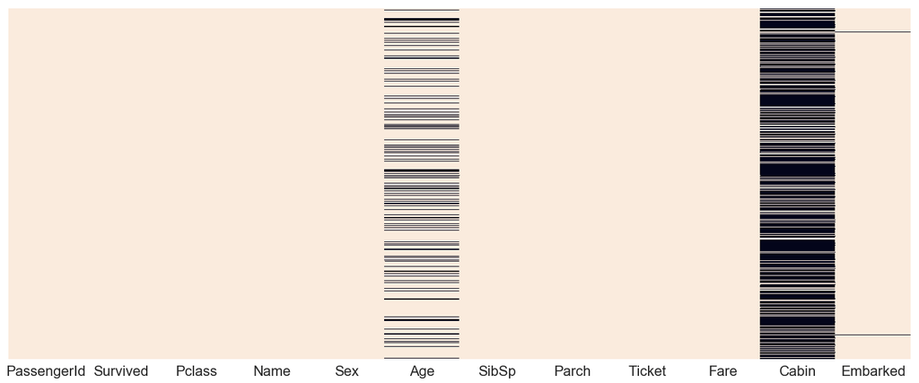

```python
fig, ax = plt.subplots(figsize=(25,10))
sns_heatmap = sns.heatmap(df.notnull(), yticklabels=False, cbar=False)
# We've removed tick labels of the y axis
```

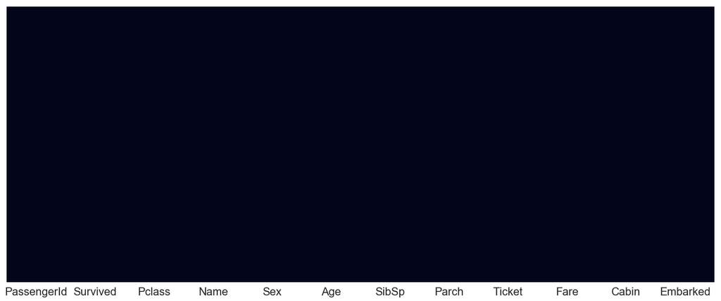

```python
fig, ax = plt.subplots(figsize=(25,10))
df_clean = df.dropna() # Dropped all samples which are not defined
sns_heatmap = sns.heatmap(df_clean.isnull(), yticklabels=False, cbar=False) # checking in the new DateFrame all values
                                                                            # are defined
```

```python
df_clean
```

|  | PassengerId | Survived | Pclass | Name | Sex | Age | SibSp | Parch | Ticket | Fare | Cabin | Embarked |
| --- | --- | --- | --- | --- | --- | --- | --- | --- | --- | --- | --- | --- |
| 1 | 2 | 1 | 1 | Cumings, Mrs. John Bradley (Florence Briggs Th... | female | 38.0 | 1 | 0 | PC 17599 | 71.2833 | C85 | C |
| 3 | 4 | 1 | 1 | Futrelle, Mrs. Jacques Heath (Lily May Peel) | female | 35.0 | 1 | 0 | 113803 | 53.1000 | C123 | S |
| 6 | 7 | 0 | 1 | McCarthy, Mr. Timothy J | male | 54.0 | 0 | 0 | 17463 | 51.8625 | E46 | S |
| 10 | 11 | 1 | 3 | Sandstrom, Miss. Marguerite Rut | female | 4.0 | 1 | 1 | PP 9549 | 16.7000 | G6 | S |
| 11 | 12 | 1 | 1 | Bonnell, Miss. Elizabeth | female | 58.0 | 0 | 0 | 113783 | 26.5500 | C103 | S |
| 21 | 22 | 1 | 2 | Beesley, Mr. Lawrence | male | 34.0 | 0 | 0 | 248698 | 13.0000 | D56 | S |
| 23 | 24 | 1 | 1 | Sloper, Mr. William Thompson | male | 28.0 | 0 | 0 | 113788 | 35.5000 | A6 | S |
| 27 | 28 | 0 | 1 | Fortune, Mr. Charles Alexander | male | 19.0 | 3 | 2 | 19950 | 263.0000 | C23 C25 C27 | S |
| 52 | 53 | 1 | 1 | Harper, Mrs. Henry Sleeper (Myna Haxtun) | female | 49.0 | 1 | 0 | PC 17572 | 76.7292 | D33 | C |
| 54 | 55 | 0 | 1 | Ostby, Mr. Engelhart Cornelius | male | 65.0 | 0 | 1 | 113509 | 61.9792 | B30 | C |
| 62 | 63 | 0 | 1 | Harris, Mr. Henry Birkhardt | male | 45.0 | 1 | 0 | 36973 | 83.4750 | C83 | S |
| 66 | 67 | 1 | 2 | Nye, Mrs. (Elizabeth Ramell) | female | 29.0 | 0 | 0 | C.A. 29395 | 10.5000 | F33 | S |
| 75 | 76 | 0 | 3 | Moen, Mr. Sigurd Hansen | male | 25.0 | 0 | 0 | 348123 | 7.6500 | F G73 | S |
| 88 | 89 | 1 | 1 | Fortune, Miss. Mabel Helen | female | 23.0 | 3 | 2 | 19950 | 263.0000 | C23 C25 C27 | S |
| 92 | 93 | 0 | 1 | Chaffee, Mr. Herbert Fuller | male | 46.0 | 1 | 0 | W.E.P. 5734 | 61.1750 | E31 | S |
| 96 | 97 | 0 | 1 | Goldschmidt, Mr. George B | male | 71.0 | 0 | 0 | PC 17754 | 34.6542 | A5 | C |
| 97 | 98 | 1 | 1 | Greenfield, Mr. William Bertram | male | 23.0 | 0 | 1 | PC 17759 | 63.3583 | D10 D12 | C |
| 102 | 103 | 0 | 1 | White, Mr. Richard Frasar | male | 21.0 | 0 | 1 | 35281 | 77.2875 | D26 | S |
| 110 | 111 | 0 | 1 | Porter, Mr. Walter Chamberlain | male | 47.0 | 0 | 0 | 110465 | 52.0000 | C110 | S |
| 118 | 119 | 0 | 1 | Baxter, Mr. Quigg Edmond | male | 24.0 | 0 | 1 | PC 17558 | 247.5208 | B58 B60 | C |
| 123 | 124 | 1 | 2 | Webber, Miss. Susan | female | 32.5 | 0 | 0 | 27267 | 13.0000 | E101 | S |
| 124 | 125 | 0 | 1 | White, Mr. Percival Wayland | male | 54.0 | 0 | 1 | 35281 | 77.2875 | D26 | S |
| 136 | 137 | 1 | 1 | Newsom, Miss. Helen Monypeny | female | 19.0 | 0 | 2 | 11752 | 26.2833 | D47 | S |
| 137 | 138 | 0 | 1 | Futrelle, Mr. Jacques Heath | male | 37.0 | 1 | 0 | 113803 | 53.1000 | C123 | S |
| 139 | 140 | 0 | 1 | Giglio, Mr. Victor | male | 24.0 | 0 | 0 | PC 17593 | 79.2000 | B86 | C |
| 148 | 149 | 0 | 2 | Navratil, Mr. Michel ("Louis M Hoffman") | male | 36.5 | 0 | 2 | 230080 | 26.0000 | F2 | S |
| 151 | 152 | 1 | 1 | Pears, Mrs. Thomas (Edith Wearne) | female | 22.0 | 1 | 0 | 113776 | 66.6000 | C2 | S |
| 170 | 171 | 0 | 1 | Van der hoef, Mr. Wyckoff | male | 61.0 | 0 | 0 | 111240 | 33.5000 | B19 | S |
| 174 | 175 | 0 | 1 | Smith, Mr. James Clinch | male | 56.0 | 0 | 0 | 17764 | 30.6958 | A7 | C |
| 177 | 178 | 0 | 1 | Isham, Miss. Ann Elizabeth | female | 50.0 | 0 | 0 | PC 17595 | 28.7125 | C49 | C |
| ... | ... | ... | ... | ... | ... | ... | ... | ... | ... | ... | ... | ... |
| 737 | 738 | 1 | 1 | Lesurer, Mr. Gustave J | male | 35.0 | 0 | 0 | PC 17755 | 512.3292 | B101 | C |
| 741 | 742 | 0 | 1 | Cavendish, Mr. Tyrell William | male | 36.0 | 1 | 0 | 19877 | 78.8500 | C46 | S |
| 742 | 743 | 1 | 1 | Ryerson, Miss. Susan Parker "Suzette" | female | 21.0 | 2 | 2 | PC 17608 | 262.3750 | B57 B59 B63 B66 | C |
| 745 | 746 | 0 | 1 | Crosby, Capt. Edward Gifford | male | 70.0 | 1 | 1 | WE/P 5735 | 71.0000 | B22 | S |
| 748 | 749 | 0 | 1 | Marvin, Mr. Daniel Warner | male | 19.0 | 1 | 0 | 113773 | 53.1000 | D30 | S |
| 751 | 752 | 1 | 3 | Moor, Master. Meier | male | 6.0 | 0 | 1 | 392096 | 12.4750 | E121 | S |
| 759 | 760 | 1 | 1 | Rothes, the Countess. of (Lucy Noel Martha Dye... | female | 33.0 | 0 | 0 | 110152 | 86.5000 | B77 | S |
| 763 | 764 | 1 | 1 | Carter, Mrs. William Ernest (Lucile Polk) | female | 36.0 | 1 | 2 | 113760 | 120.0000 | B96 B98 | S |
| 765 | 766 | 1 | 1 | Hogeboom, Mrs. John C (Anna Andrews) | female | 51.0 | 1 | 0 | 13502 | 77.9583 | D11 | S |
| 772 | 773 | 0 | 2 | Mack, Mrs. (Mary) | female | 57.0 | 0 | 0 | S.O./P.P. 3 | 10.5000 | E77 | S |
| 779 | 780 | 1 | 1 | Robert, Mrs. Edward Scott (Elisabeth Walton Mc... | female | 43.0 | 0 | 1 | 24160 | 211.3375 | B3 | S |
| 781 | 782 | 1 | 1 | Dick, Mrs. Albert Adrian (Vera Gillespie) | female | 17.0 | 1 | 0 | 17474 | 57.0000 | B20 | S |
| 782 | 783 | 0 | 1 | Long, Mr. Milton Clyde | male | 29.0 | 0 | 0 | 113501 | 30.0000 | D6 | S |
| 789 | 790 | 0 | 1 | Guggenheim, Mr. Benjamin | male | 46.0 | 0 | 0 | PC 17593 | 79.2000 | B82 B84 | C |
| 796 | 797 | 1 | 1 | Leader, Dr. Alice (Farnham) | female | 49.0 | 0 | 0 | 17465 | 25.9292 | D17 | S |
| 802 | 803 | 1 | 1 | Carter, Master. William Thornton II | male | 11.0 | 1 | 2 | 113760 | 120.0000 | B96 B98 | S |
| 806 | 807 | 0 | 1 | Andrews, Mr. Thomas Jr | male | 39.0 | 0 | 0 | 112050 | 0.0000 | A36 | S |
| 809 | 810 | 1 | 1 | Chambers, Mrs. Norman Campbell (Bertha Griggs) | female | 33.0 | 1 | 0 | 113806 | 53.1000 | E8 | S |
| 820 | 821 | 1 | 1 | Hays, Mrs. Charles Melville (Clara Jennings Gr... | female | 52.0 | 1 | 1 | 12749 | 93.5000 | B69 | S |
| 823 | 824 | 1 | 3 | Moor, Mrs. (Beila) | female | 27.0 | 0 | 1 | 392096 | 12.4750 | E121 | S |
| 835 | 836 | 1 | 1 | Compton, Miss. Sara Rebecca | female | 39.0 | 1 | 1 | PC 17756 | 83.1583 | E49 | C |
| 853 | 854 | 1 | 1 | Lines, Miss. Mary Conover | female | 16.0 | 0 | 1 | PC 17592 | 39.4000 | D28 | S |
| 857 | 858 | 1 | 1 | Daly, Mr. Peter Denis | male | 51.0 | 0 | 0 | 113055 | 26.5500 | E17 | S |
| 862 | 863 | 1 | 1 | Swift, Mrs. Frederick Joel (Margaret Welles Ba... | female | 48.0 | 0 | 0 | 17466 | 25.9292 | D17 | S |
| 867 | 868 | 0 | 1 | Roebling, Mr. Washington Augustus II | male | 31.0 | 0 | 0 | PC 17590 | 50.4958 | A24 | S |
| 871 | 872 | 1 | 1 | Beckwith, Mrs. Richard Leonard (Sallie Monypeny) | female | 47.0 | 1 | 1 | 11751 | 52.5542 | D35 | S |
| 872 | 873 | 0 | 1 | Carlsson, Mr. Frans Olof | male | 33.0 | 0 | 0 | 695 | 5.0000 | B51 B53 B55 | S |
| 879 | 880 | 1 | 1 | Potter, Mrs. Thomas Jr (Lily Alexenia Wilson) | female | 56.0 | 0 | 1 | 11767 | 83.1583 | C50 | C |
| 887 | 888 | 1 | 1 | Graham, Miss. Margaret Edith | female | 19.0 | 0 | 0 | 112053 | 30.0000 | B42 | S |
| 889 | 890 | 1 | 1 | Behr, Mr. Karl Howell | male | 26.0 | 0 | 0 | 111369 | 30.0000 | C148 | C |

183 rows × 12 columns

```python
# TODO: What fraction of data (observations) is rested after cleaning?
# use df.shape and df_clean.shape
df_clean.shape[0] / df.shape[0]
```

```
0.2053872053872054
```

0.2053872053872054 - not so much.

Let's drop only not sparse columns *Age* and *Embarked* and exclude *Cabin* column at all

```python
df_clean = df.drop('Cabin', axis=1).dropna(subset=['Age', 'Embarked'])
df_clean.shape
```

```
(712, 11)
```

# Countplot (bar plot counts of variable values)

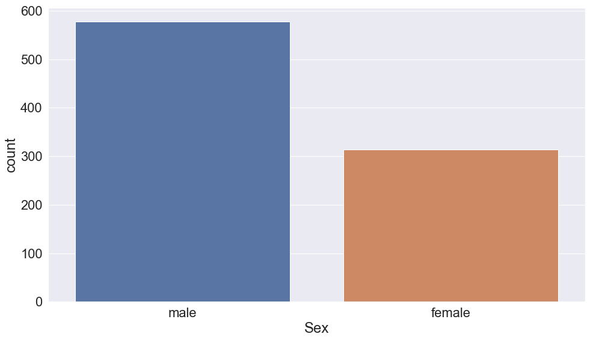

```python
sns.set(font_scale=2, rc={'figure.figsize':(16,9)})
sns.countplot(df['Sex']);
```

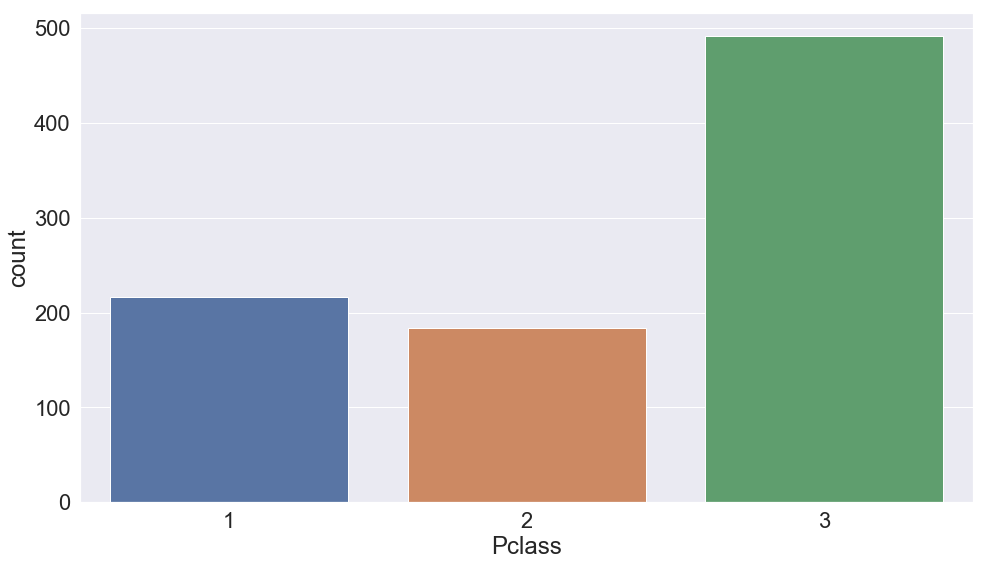

```python
sns.set(font_scale=2, rc={'figure.figsize':(16,9)})
sns.countplot(df['Pclass']);
```

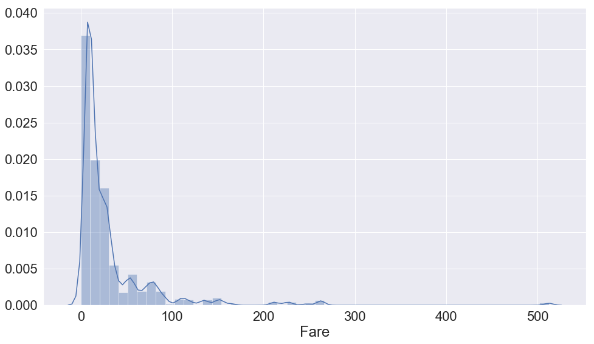

```python
sns.distplot(df['Fare']);
# plot the fare distribution
```

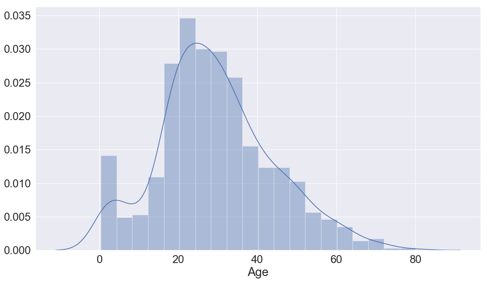

```python
sns.distplot(df_clean['Age']);
```

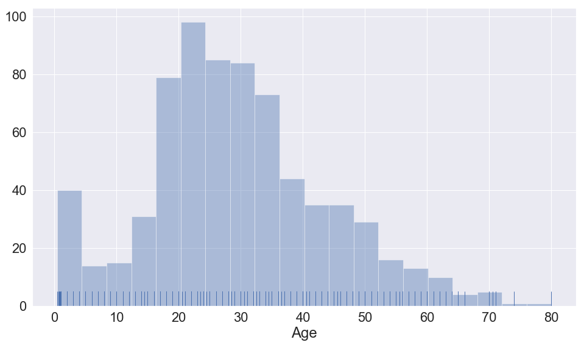

```python
sns.distplot(df_clean['Age'], bins=20, kde=False, rug=True);
# kde - Whether to plot a gaussian kernel density estimate
# rug - Whether to draw a rugplot on the support axis
# A rug plot is a plot of data for a single qualitative variable, displayed as marks along an axis.
# It is used to visualise the distribution of the data. As such it is analogous to a histogram with zero-width bins,
# or a one-dimensional scatter plot
```

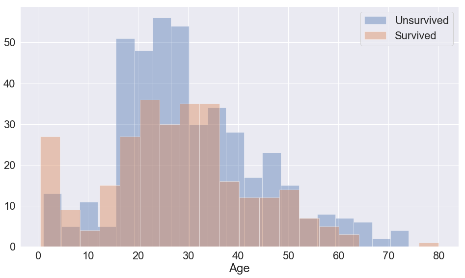

```python
sns.distplot(df_clean['Age'][df_clean['Survived'] == 0], bins=20, kde=False, label='Unsurvived')
sns.distplot(df_clean['Age'][df_clean['Survived'] == 1], bins=20, kde=False, label='Survived')
plt.legend();
```

```python
df['Pclass'].unique()
```

```
array([3, 1, 2], dtype=int64)
```

**My results differ from that obtained by the instructors (2 following blocks and 2 following them after)**

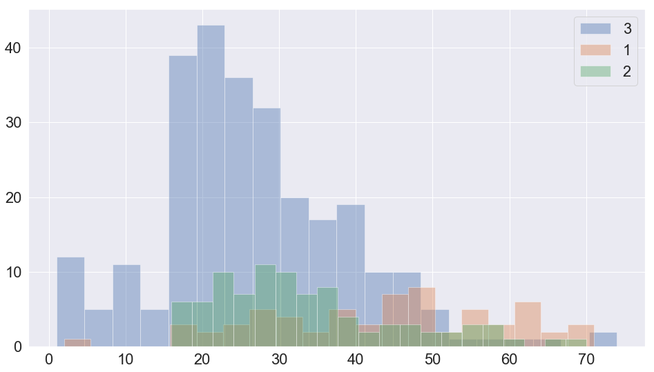

```python
for pclass in [3,1,2]:
    sns.distplot(df_clean["Age"][(df_clean['Survived'] == 0) & (df_clean['Pclass'] == pclass)],
                 bins=20, kde=False, label=str(pclass))
plt.legend();
```

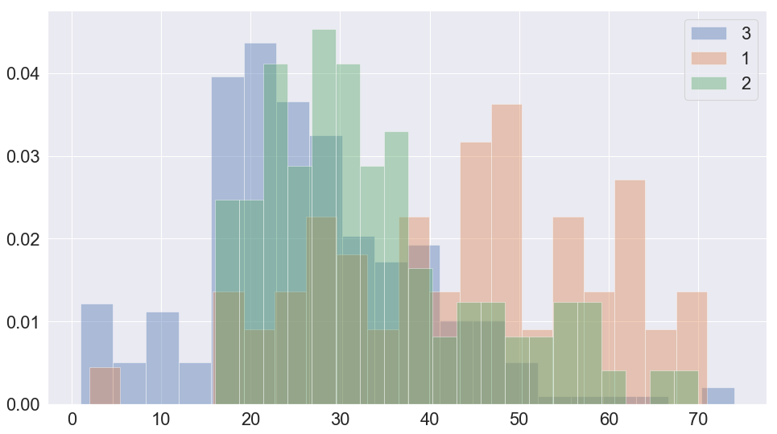

```python
for pclass in [3,1,2]:
    sns.distplot(df_clean["Age"][(df_clean['Survived'] == 0) & (df_clean['Pclass'] == pclass)],
                 bins=20, kde=False, label=str(pclass), norm_hist = True)
plt.legend();
```

[figure not shown]

```python
# How the Age of unsurvived passengers depends on Pclass?
# TODO: Plot histograms of Age for each pClass of unsurvived to see how it is distributed
# use filter rule (df['Survived'] == 0) & (df['Pclass'] == pclass)
```

[figure not shown]

```python
# TODO: Enable norm_hist = True
```

### Hometask

What the class of passengers is the most unsurvived?

# Box vs violin plots

*The following I copied from Wiki*  
A box plot or boxplot is a method for graphically depicting groups of numerical data through their quartiles. Box plots may also have lines extending vertically from the boxes (whiskers) indicating variability outside the upper and lower quartiles, hence the terms box-and-whisker plot and box-and-whisker diagram. Outliers may be plotted as individual points.

A violin plot is a method of plotting numeric data. It is similar to a box plot with a rotated kernel density plot on each side.

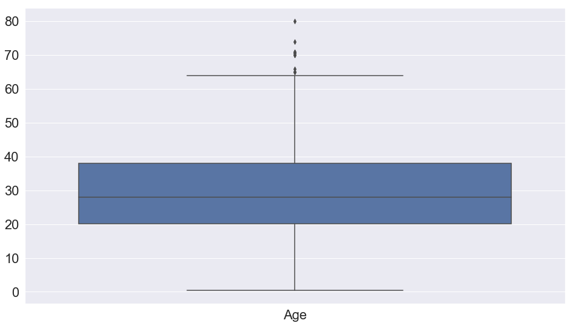

```python
sns.boxplot(data=df[['Age']]);
```

Change orientation

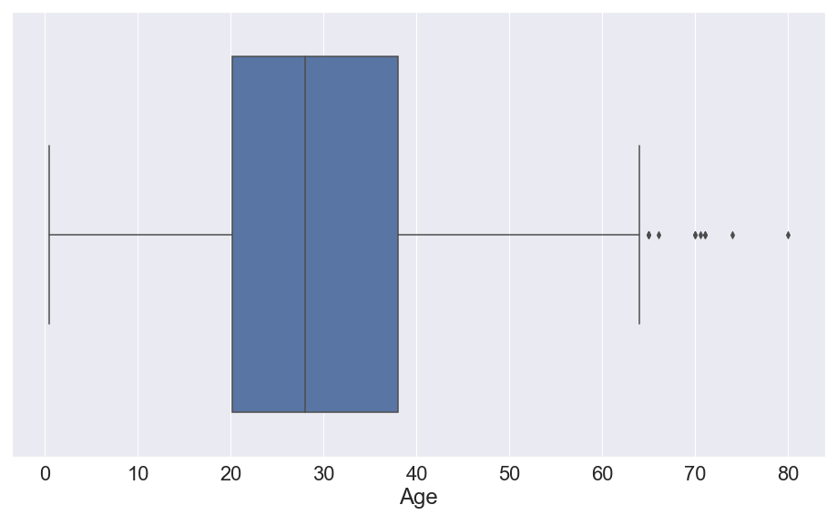

```python
sns.boxplot(x='Age', data=df[['Age']]);
```

Violinplot draws a combination of boxplot and kernel density estimate.

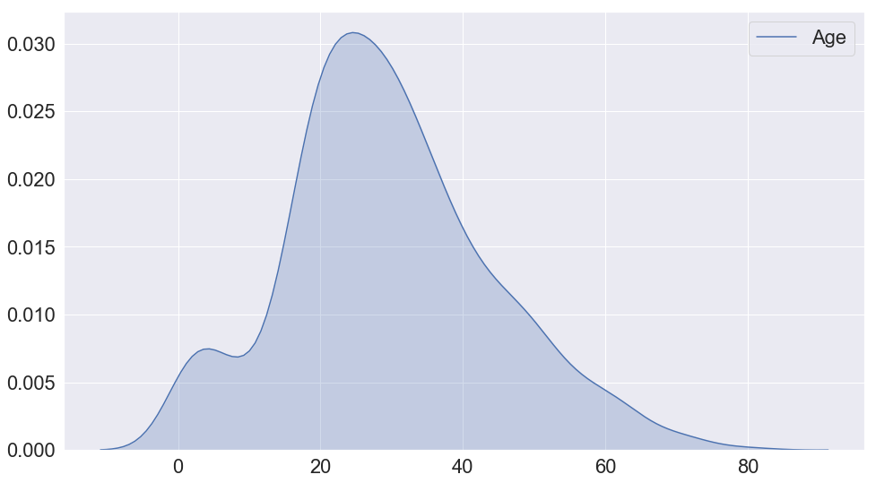

```python
sns.kdeplot(data=df['Age'], shade=True);
```

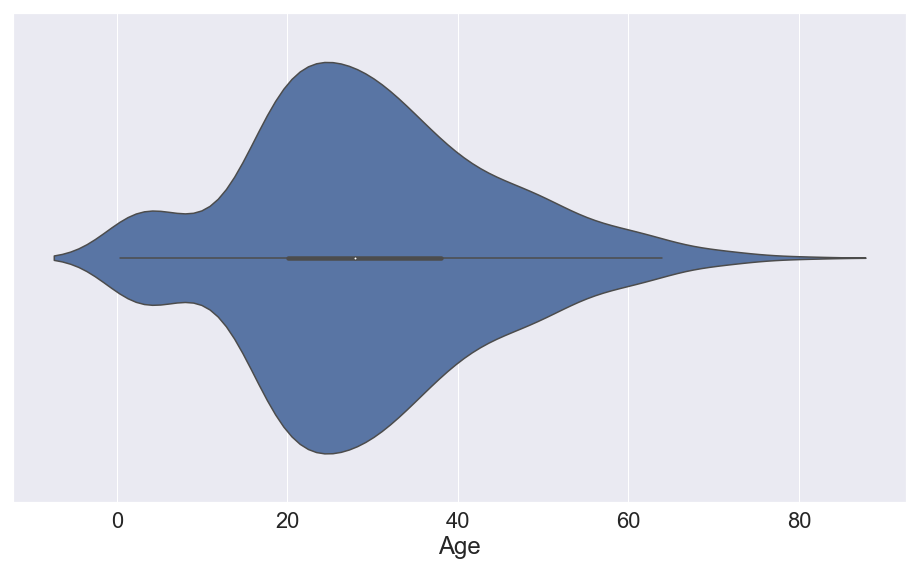

```python
sns.violinplot(x='Age', data=df[['Age']]);
```

# Jointplot

Scatter plot with the distributions of variables

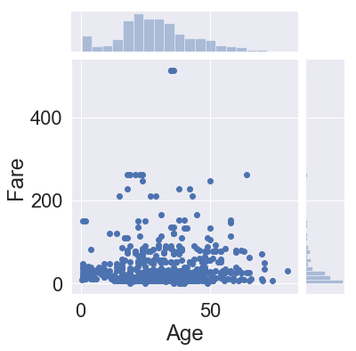

```python
sns.jointplot(data=df, x='Age', y='Fare');
```

# Homework

Download [sample dataset](https://github.com/oreillymedia/doing_data_science/raw/master/dds_datasets.zip). Unzip it, unzip `dds_datasets/dds_ch2_rollingsales.zip`. Load Bronx in dataframe:

```python
df = pd.read_excel('rollingsales_bronx.xls', skiprows=4)
df.head()
```

|  | BOROUGH | NEIGHBORHOOD | BUILDING CLASS CATEGORY | TAX CLASS AT PRESENT | BLOCK | LOT | EASE-MENT | BUILDING CLASS AT PRESENT | ADDRESS | APART MENT NUMBER | ... | RESIDENTIAL UNITS | COMMERCIAL UNITS | TOTAL UNITS | LAND SQUARE FEET | GROSS SQUARE FEET | YEAR BUILT | TAX CLASS AT TIME OF SALE | BUILDING CLASS AT TIME OF SALE | SALE PRICE | SALE DATE |
| --- | --- | --- | --- | --- | --- | --- | --- | --- | --- | --- | --- | --- | --- | --- | --- | --- | --- | --- | --- | --- | --- |
| 0 | 2 | BATHGATE | 01 ONE FAMILY HOMES | 1 | 3028 | 25 |  | A5 | 412 EAST 179TH STREET |  | ... | 1 | 0 | 1 | 1842 | 2048 | 1901 | 1 | A5 | 355000 | 2013-07-08 |
| 1 | 2 | BATHGATE | 01 ONE FAMILY HOMES | 1 | 3039 | 28 |  | A1 | 2329 WASHINGTON AVENUE |  | ... | 1 | 0 | 1 | 1103 | 1290 | 1910 | 1 | A1 | 474819 | 2013-05-20 |
| 2 | 2 | BATHGATE | 01 ONE FAMILY HOMES | 1 | 3046 | 39 |  | A1 | 2075 BATHGATE AVENUE |  | ... | 1 | 0 | 1 | 1986 | 1344 | 1899 | 1 | A1 | 210000 | 2013-03-12 |
| 3 | 2 | BATHGATE | 01 ONE FAMILY HOMES | 1 | 3046 | 52 |  | A1 | 2047 BATHGATE AVENUE |  | ... | 1 | 0 | 1 | 2329 | 1431 | 1901 | 1 | A1 | 343116 | 2013-07-01 |
| 4 | 2 | BATHGATE | 02 TWO FAMILY HOMES | 1 | 2900 | 61 |  | S2 | 406 EAST TREMONT AVENUE |  | ... | 2 | 1 | 3 | 1855 | 4452 | 1931 | 1 | S2 | 0 | 2012-08-31 |

5 rows × 21 columns

```python
df.info()
```

```
<class 'pandas.core.frame.DataFrame'>
RangeIndex: 5268 entries, 0 to 5267
Data columns (total 21 columns):
BOROUGH                           5268 non-null int64
NEIGHBORHOOD                      5268 non-null object
BUILDING CLASS CATEGORY           5268 non-null object
TAX CLASS AT PRESENT              5268 non-null object
BLOCK                             5268 non-null int64
LOT                               5268 non-null int64
EASE-MENT                         5268 non-null object
BUILDING CLASS AT PRESENT         5268 non-null object
ADDRESS                           5268 non-null object
APART
MENT
NUMBER                 5268 non-null object
ZIP CODE                          5268 non-null int64
RESIDENTIAL UNITS                 5268 non-null int64
COMMERCIAL UNITS                  5268 non-null int64
TOTAL UNITS                       5268 non-null int64
LAND SQUARE FEET                  5268 non-null int64
GROSS SQUARE FEET                 5268 non-null int64
YEAR BUILT                        5268 non-null int64
TAX CLASS AT TIME OF SALE         5268 non-null object
BUILDING CLASS AT TIME OF SALE    5268 non-null object
SALE
PRICE                        5268 non-null int64
SALE DATE                         5268 non-null datetime64[ns]
dtypes: datetime64[ns](1), int64(11), object(9)
memory usage: 864.4+ KB
```

## Regression plot within jointplot

You can call just `regplot()`

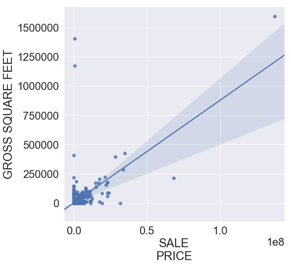

```python
f, ax = plt.subplots(figsize=(8, 8))
sns.regplot(data=df, x='SALE\nPRICE', y='GROSS SQUARE FEET');
```

But try to understand the anatomy of `jointplot()`

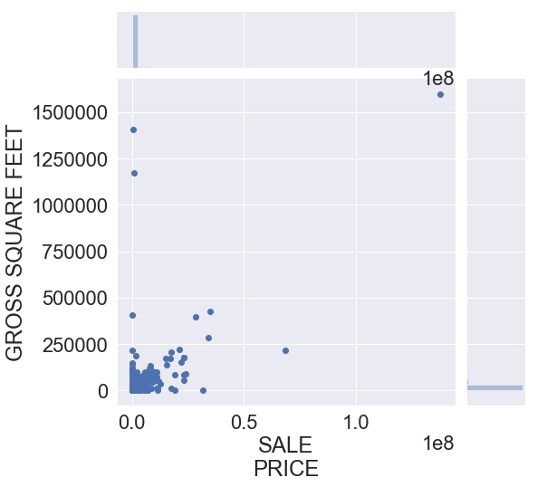

```python
jnt = sns.jointplot(x='SALE\nPRICE', y='GROSS SQUARE FEET', data=df, height=8);
```

There are three subplots (`axes`-objects) within jointplot:

```python
[member for member in filter(lambda m: '__' not in m, dir(jnt))]
#[member for member in filter(lambda m: "ax_" in m, dir(jnt))]
# i.e. ax_joint, ax_marg_x, ax_marg_y
```

```
['annotate',
 'ax_joint',
 'ax_marg_x',
 'ax_marg_y',
 'fig',
 'plot',
 'plot_joint',
 'plot_marginals',
 'savefig',
 'set_axis_labels',
 'x',
 'y']
```

Do the following:

- Filter outliers by 0.5e8 for x and by 6e5 for y
- Plot regression line onto scatterplot (pass certain parameter to `jointplot`)
- Disable tick labels of both X&Y `distplot`s to hide "1e8" (get x axis from x distplot (marginal plot) and use `set_visible()`)
- Low case both labels of scatterplot axis X&Y (e.g. `'GROSS' -> 'Gross'`)
- Pad label of scatterplot axis Y

```python
df.columns
```

```
Index(['BOROUGH', 'NEIGHBORHOOD', 'BUILDING CLASS CATEGORY',
       'TAX CLASS AT PRESENT', 'BLOCK', 'LOT', 'EASE-MENT',
       'BUILDING CLASS AT PRESENT', 'ADDRESS', 'APART\nMENT\nNUMBER',
       'ZIP CODE', 'RESIDENTIAL UNITS', 'COMMERCIAL UNITS', 'TOTAL UNITS',
       'LAND SQUARE FEET', 'GROSS SQUARE FEET', 'YEAR BUILT',
       'TAX CLASS AT TIME OF SALE', 'BUILDING CLASS AT TIME OF SALE',
       'SALE\nPRICE', 'SALE DATE'],
      dtype='object')
```

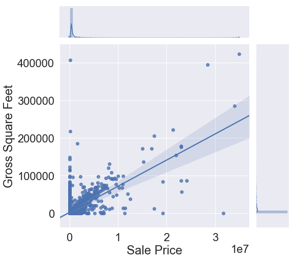

```python
df_filtered = df[(df["SALE\nPRICE"] < 0.5e8) & (df["GROSS SQUARE FEET"] < 6e5)]
jnt = sns.jointplot(x ="SALE\nPRICE", y="GROSS SQUARE FEET",data=df_filtered,kind="reg",height=8)
jnt.ax_marg_x.xaxis.set_visible(False)
jnt.ax_marg_y.yaxis.set_visible(False)
jnt.ax_joint.set_xlabel("Sale Price") # Should it be Sale\nPrice or Sale Price?
jnt.ax_joint.set_ylabel("Gross Square Feet");
# "Pad label of scatterplot axis Y" - I didn't get it
```

Optional:

- Replace format of axis Y to exponential (get y axis from y scatterplot and use its method) `set_major_formatter(matplotlib.tickerFuncFormatter(lambda string, position: ...))`)

```python
from math import log10
from matplotlib.ticker import FuncFormatter

def fun(x,pos):
    if x == 0: return "$0$"
    if x > 0:
        x = int(x)
        pow = int(log10(x))
        man = int(x // 10 ** pow)
        return r"${} \times 10^{}$".format(man,pow)
```

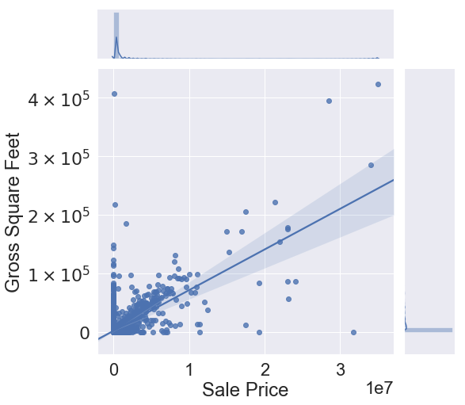

```python
jnt.ax_joint.yaxis.set_major_formatter(FuncFormatter(fun))
jnt.fig
```